# WPA #8 – Regression

# Binary Logistic regression

22. Let’s create a logistic regression analysis that answers the question: “What predicts whether or not a student *improves* his/her math grade from period 1 to period 3?” To do this, we need to start by creating a new logical variable which indicates whether or not a student’s period 3 grade is larger than his/her period 1 grade. Add a new variable to the math dataframe called `grade_improve` that shows this (Hint: You can easily do this by creating a logical vector comparing period 1 and period 3 grades).

```r
student_m$grade_improve <- student_m$G3 > student_m$G1
```

23. Using the `glm()` function, conduct a binary logistic regression analysis that answers the main research question above. Use the `summary()` function to understand the results. What do you conclude?

```r
glm_23 <- glm(grade_improve ~ .,
              data = student_m,
              family = "binomial")

summary(glm_23)
```

```
##
## Call:
## glm(formula = grade_improve ~ ., family = "binomial", data = student_m)
##
## Deviance Residuals:
##        Min          1Q      Median          3Q         Max
## -3.882e-05  -2.100e-08  -2.100e-08   2.100e-08   2.846e-05
##
## Coefficients:
##                    Estimate Std. Error z value Pr(>|z|)
## (Intercept)      -1.800e+01  1.730e+05   0.000    1.000
## schoolMS         -9.059e-01  2.628e+04   0.000    1.000
## sexM             -1.358e+00  1.614e+04   0.000    1.000
## age              -3.501e-01  6.824e+03   0.000    1.000
## addressU          1.392e+00  1.909e+04   0.000    1.000
## famsizeLE3       -5.622e-01  1.491e+04   0.000    1.000
## PstatusT         -1.306e-01  1.756e+04   0.000    1.000
## Medu             -3.296e-01  8.867e+03   0.000    1.000
## Fedu             -1.303e-01  8.747e+03   0.000    1.000
## Mjobhealth        2.981e-01  2.999e+04   0.000    1.000
## Mjobother        -2.086e-01  2.344e+04   0.000    1.000
## Mjobservices      5.164e-01  2.742e+04   0.000    1.000
## Mjobteacher       1.425e+00  3.011e+04   0.000    1.000
## Fjobhealth       -1.663e+00  4.490e+04   0.000    1.000
## Fjobother        -1.166e+00  2.882e+04   0.000    1.000
## Fjobservices     -1.544e+00  2.973e+04   0.000    1.000
## Fjobteacher      -1.047e+00  3.385e+04   0.000    1.000
## reasonhome       -4.007e-01  1.597e+04   0.000    1.000
## reasonother       6.018e-01  2.466e+04   0.000    1.000
## reasonreputation -3.331e-01  1.721e+04   0.000    1.000
## guardianmother   -7.786e-01  1.549e+04   0.000    1.000
## guardianother    -1.512e+00  3.476e+04   0.000    1.000
## traveltime       -1.485e-01  1.191e+04   0.000    1.000
## studytime         4.544e-02  8.594e+03   0.000    1.000
## failures         -4.477e-01  1.178e+04   0.000    1.000
## schoolsupyes     -1.891e+00  2.575e+04   0.000    1.000
## famsupyes        -1.509e-01  1.461e+04   0.000    1.000
## paidyes          -9.176e-01  1.465e+04   0.000    1.000
## activitiesyes     3.261e-01  1.336e+04   0.000    1.000
## nurseryyes        4.537e-01  1.714e+04   0.000    1.000
## higheryes         3.628e+00  9.400e+04   0.000    1.000
## internetyes      -1.299e+00  2.243e+04   0.000    1.000
## romanticyes      -4.369e-01  1.418e+04   0.000    1.000
## famrel            6.976e-01  8.242e+03   0.000    1.000
## freetime         -9.229e-02  7.311e+03   0.000    1.000
## goout            -1.477e-01  6.808e+03   0.000    1.000
## Dalc              7.961e-01  1.029e+04   0.000    1.000
## Walc             -3.250e-02  6.878e+03   0.000    1.000
## health           -1.765e-01  5.231e+03   0.000    1.000
## absences          2.572e-03  1.050e+03   0.000    1.000
## G1               -4.529e+01  1.057e+04  -0.004    0.997
## G2                1.522e-01  8.702e+03   0.000    1.000
## G3                4.509e+01  1.094e+04   0.004    0.997
##
## (Dispersion parameter for binomial family taken to be 1)
##
##     Null deviance: 5.1711e+02  on 394  degrees of freedom
## Residual deviance: 3.1834e-08  on 352  degrees of freedom
## AIC: 86
##
## Number of Fisher Scoring iterations: 25
```

```r
# Actually we have a problem here! The problem is that the model can perfectly predict grade improvement because it currently has access to both G1 and G3. We need to rerun the analysis but EXCLUDING G1 and G3...

glm_23 <- glm(grade_improve ~ .,
              data = subset(student_m, select = c(-G1, -G3)),   # Exclude columns G1 and G3!
              family = "binomial")

summary(glm_23)
```

```
##
## Call:
## glm(formula = grade_improve ~ ., family = "binomial", data = subset(student_m,
##     select = c(-G1, -G3)))
##
## Deviance Residuals:
##     Min       1Q   Median       3Q      Max
## -1.6835  -0.8774  -0.5195   1.0131   2.5495
##
## Coefficients:
##                   Estimate Std. Error z value Pr(>|z|)
## (Intercept)      -0.170258   2.638855  -0.065   0.9486
## schoolMS         -0.802432   0.513457  -1.563   0.1181
## sexM             -0.612143   0.290820  -2.105   0.0353 *
## age              -0.162788   0.125540  -1.297   0.1947
## addressU          0.490124   0.344860   1.421   0.1553
## famsizeLE3       -0.202798   0.278695  -0.728   0.4668
## PstatusT         -0.222202   0.411606  -0.540   0.5893
## Medu             -0.013632   0.188422  -0.072   0.9423
## Fedu             -0.117795   0.159411  -0.739   0.4599
## Mjobhealth       -0.085128   0.649117  -0.131   0.8957
## Mjobother         0.294336   0.419185   0.702   0.4826
## Mjobservices      0.240903   0.467361   0.515   0.6062
## Mjobteacher       0.424096   0.615256   0.689   0.4906
## Fjobhealth        0.261414   0.850298   0.307   0.7585
## Fjobother         0.699142   0.635129   1.101   0.2710
## Fjobservices      0.268166   0.657341   0.408   0.6833
## Fjobteacher      -0.012721   0.791620  -0.016   0.9872
## reasonhome       -0.193825   0.311622  -0.622   0.5340
## reasonother       0.961705   0.456002   2.109   0.0349 *
## reasonreputation -0.322455   0.327102  -0.986   0.3242
## guardianmother   -0.179797   0.299377  -0.601   0.5481
## guardianother    -0.801163   0.620545  -1.291   0.1967
## traveltime       -0.138520   0.198514  -0.698   0.4853
## studytime        -0.142796   0.161538  -0.884   0.3767
## failures          0.368359   0.202141   1.822   0.0684 .
## schoolsupyes      0.483901   0.367486   1.317   0.1879
## famsupyes         0.442378   0.275913   1.603   0.1089
## paidyes          -0.264673   0.270126  -0.980   0.3272
## activitiesyes    -0.052579   0.252336  -0.208   0.8349
## nurseryyes       -0.127564   0.311228  -0.410   0.6819
## higheryes        -0.020668   0.641993  -0.032   0.9743
## internetyes      -0.150675   0.352512  -0.427   0.6691
## romanticyes      -0.347262   0.271162  -1.281   0.2003
## famrel            0.279927   0.143638   1.949   0.0513 .
## freetime         -0.123018   0.136262  -0.903   0.3666
## goout            -0.059728   0.128480  -0.465   0.6420
## Dalc              0.254498   0.187445   1.358   0.1746
## Walc              0.107042   0.140697   0.761   0.4468
## health           -0.005229   0.091439  -0.057   0.9544
## absences         -0.054196   0.022106  -2.452   0.0142 *
## G2                0.189013   0.041559   4.548 5.41e-06 ***
## ---
## Signif. codes:  0 '***' 0.001 '**' 0.01 '*' 0.05 '.' 0.1 ' ' 1
##
## (Dispersion parameter for binomial family taken to be 1)
##
##     Null deviance: 517.11  on 394  degrees of freedom
## Residual deviance: 436.58  on 354  degrees of freedom
## AIC: 518.58
##
## Number of Fisher Scoring iterations: 4
```

```r
# Now that looks better!

# Men improve their scores LESS than women (b = -0.61, t(354) = -2.11, p = 0.04), people whose reason to choose the school is "other" improve more than those with another reason to choose the school (b = 0.96, t(354) = 2.11, p = 0.03), the more absences a student has the less they improve their scores (b = -0.05, t(354) = -2.45, p = 0.01), and the higher their period 2 grades, the more they improve their scores (b = 0.19, t(354) = 4.55, p < .01).
```

24. Repeat this analyses, but now use the portugese data. Do you find differences in which variables predict grade improvement between the two datasets?

```r
student_p$grade_improve <- student_p$G3 > student_p$G1

glm_24 <- glm(grade_improve ~ .,
              data = student_p,
              family = "binomial")

summary(glm_24)
```

```
##
## Call:
## glm(formula = grade_improve ~ ., family = "binomial", data = student_p)
##
## Deviance Residuals:
##        Min          1Q      Median          3Q         Max
## -1.351e-05  -6.245e-06   2.110e-08   6.383e-06   1.306e-05
##
## Coefficients:
##                    Estimate Std. Error z value Pr(>|z|)
## (Intercept)      -2.394e+01  1.061e+05   0.000    1.000
## schoolMS         -7.397e-02  1.344e+04   0.000    1.000
## sexM              1.032e-01  1.257e+04   0.000    1.000
## age               9.049e-02  5.433e+03   0.000    1.000
## addressU         -2.492e-01  1.385e+04   0.000    1.000
## famsizeLE3        1.425e-01  1.212e+04   0.000    1.000
## PstatusT         -1.212e-01  1.750e+04   0.000    1.000
## Medu              3.002e-02  7.278e+03   0.000    1.000
## Fedu              6.272e-02  6.870e+03   0.000    1.000
## Mjobhealth        1.528e-01  2.748e+04   0.000    1.000
## Mjobother         2.017e-01  1.640e+04   0.000    1.000
## Mjobservices      2.734e-03  1.900e+04   0.000    1.000
## Mjobteacher       2.065e-01  2.522e+04   0.000    1.000
## Fjobhealth        2.105e-01  3.647e+04   0.000    1.000
## Fjobother        -1.762e-01  2.282e+04   0.000    1.000
## Fjobservices     -2.526e-01  2.392e+04   0.000    1.000
## Fjobteacher      -2.295e-01  3.278e+04   0.000    1.000
## reasonhome        4.040e-01  1.473e+04   0.000    1.000
## reasonother       4.026e-02  1.927e+04   0.000    1.000
## reasonreputation  1.894e-01  1.515e+04   0.000    1.000
## guardianmother    2.657e-01  1.381e+04   0.000    1.000
## guardianother     6.944e-01  2.978e+04   0.000    1.000
## traveltime       -3.476e-02  9.126e+03   0.000    1.000
## studytime        -1.922e-01  7.278e+03   0.000    1.000
## failures          1.966e-01  1.167e+04   0.000    1.000
## schoolsupyes      5.889e-02  1.798e+04   0.000    1.000
## famsupyes        -1.009e-01  1.169e+04   0.000    1.000
## paidyes          -2.499e-01  2.064e+04   0.000    1.000
## activitiesyes     8.426e-02  1.137e+04   0.000    1.000
## nurseryyes        2.259e-02  1.388e+04   0.000    1.000
## higheryes        -3.155e-01  2.117e+04   0.000    1.000
## internetyes      -6.539e-02  1.432e+04   0.000    1.000
## romanticyes      -1.630e-01  1.209e+04   0.000    1.000
## famrel           -4.483e-02  6.312e+03   0.000    1.000
## freetime          6.285e-02  5.674e+03   0.000    1.000
## goout            -1.263e-01  5.730e+03   0.000    1.000
## Dalc              3.437e-02  7.886e+03   0.000    1.000
## Walc              1.819e-03  6.109e+03   0.000    1.000
## health           -2.544e-02  3.949e+03   0.000    1.000
## absences         -3.494e-02  1.382e+03   0.000    1.000
## G1               -4.799e+01  1.085e+04  -0.004    0.996
## G2                1.920e-01  7.192e+03   0.000    1.000
## G3                4.776e+01  1.132e+04   0.004    0.997
##
## (Dispersion parameter for binomial family taken to be 1)
##
##     Null deviance: 8.9736e+02  on 648  degrees of freedom
## Residual deviance: 2.7744e-08  on 606  degrees of freedom
## AIC: 86
##
## Number of Fisher Scoring iterations: 25
```

```r
# Same problem as before, We'll need to rerun the analysis but EXCLUDING G1 and G3...

glm_24 <- glm(grade_improve ~ .,
              data = subset(student_p, select = c(-G1, -G3)),   # Exclude columns G1 and G3!
              family = "binomial")

summary(glm_24)
```

```
##
## Call:
## glm(formula = grade_improve ~ ., family = "binomial", data = subset(student_p,
##     select = c(-G1, -G3)))
##
## Deviance Residuals:
##     Min       1Q   Median       3Q      Max
## -2.0499  -1.0879   0.6097   1.0513   1.8200
##
## Coefficients:
##                   Estimate Std. Error z value Pr(>|z|)
## (Intercept)      -4.883496   1.630964  -2.994 0.002751 **
## schoolMS          0.367518   0.217474   1.690 0.091040 .
## sexM              0.216094   0.202176   1.069 0.285143
## age               0.284149   0.082682   3.437 0.000589 ***
## addressU         -0.181494   0.209593  -0.866 0.386525
## famsizeLE3       -0.062713   0.195401  -0.321 0.748254
## PstatusT         -0.075552   0.276326  -0.273 0.784533
## Medu             -0.067137   0.120314  -0.558 0.576837
## Fedu              0.098707   0.109996   0.897 0.369524
## Mjobhealth        0.237134   0.426528   0.556 0.578236
## Mjobother         0.076978   0.241251   0.319 0.749667
## Mjobservices     -0.083437   0.296503  -0.281 0.778402
## Mjobteacher       0.282297   0.398199   0.709 0.478364
## Fjobhealth       -0.382061   0.607351  -0.629 0.529310
## Fjobother        -0.697897   0.383796  -1.818 0.069002 .
## Fjobservices     -0.892196   0.400758  -2.226 0.025996 *
## Fjobteacher      -1.218474   0.554623  -2.197 0.028025 *
## reasonhome        0.201758   0.227397   0.887 0.374944
## reasonother      -0.551785   0.294514  -1.874 0.060993 .
## reasonreputation -0.057891   0.237428  -0.244 0.807366
## guardianmother    0.313602   0.211172   1.485 0.137528
## guardianother     0.827878   0.447420   1.850 0.064265 .
## traveltime        0.081250   0.126782   0.641 0.521613
## studytime        -0.219660   0.113142  -1.941 0.052204 .
## failures         -0.027489   0.169461  -0.162 0.871138
## schoolsupyes      0.238238   0.293098   0.813 0.416316
## famsupyes         0.042976   0.182762   0.235 0.814093
## paidyes          -0.123058   0.362639  -0.339 0.734353
## activitiesyes     0.014425   0.178307   0.081 0.935521
## nurseryyes        0.059858   0.216298   0.277 0.781979
## higheryes        -0.373691   0.313295  -1.193 0.232957
## internetyes       0.082019   0.220764   0.372 0.710246
## romanticyes      -0.097444   0.183958  -0.530 0.596316
## famrel            0.082980   0.093015   0.892 0.372328
## freetime          0.027011   0.089909   0.300 0.763853
## goout            -0.205177   0.086302  -2.377 0.017434 *
## Dalc              0.086699   0.122850   0.706 0.480354
## Walc             -0.009490   0.094190  -0.101 0.919744
## health           -0.134846   0.062064  -2.173 0.029803 *
## absences         -0.009268   0.019936  -0.465 0.641999
## G2                0.153448   0.036845   4.165 3.12e-05 ***
## ---
## Signif. codes:  0 '***' 0.001 '**' 0.01 '*' 0.05 '.' 0.1 ' ' 1
##
## (Dispersion parameter for binomial family taken to be 1)
##
##     Null deviance: 897.36  on 648  degrees of freedom
## Residual deviance: 823.31  on 608  degrees of freedom
## AIC: 905.31
##
## Number of Fisher Scoring iterations: 4
```

```r
#  There are some differences. For the portugese class, age, fathers job, how often students go out with friends and current health status each significantly predict score improvement. Sex, reason to choose the school, and absences are no longer significant. Period 2 scores are still significant.
```

# Predicting values

25. For the math dataset, create a regression object called `lm_25` predicting a student’s first period math grades based on *all* variables in the dataset.

```r
lm_25 <- lm(G1 ~.,
            data = student_m)
```

26. By looking at the `names()` of the elements in the `lm_25` object, find the vector of fitted values from the regression object. This is a vector of the predicted first period grades of all students based on the regression analysis. Add these predictions as a new column in the `student_m` dataframe called `G1_predicted`.

```r
names(lm_25)
```

```
##  [1] "coefficients"  "residuals"     "effects"       "rank"
##  [5] "fitted.values" "assign"        "qr"            "df.residual"
##  [9] "contrasts"     "xlevels"       "call"          "terms"
## [13] "model"
```

```r
# it's fitted.values!

lm_25$fitted.values[1:10]
```

```
##         1         2         3         4         5         6         7
##  6.601191  6.224862  6.477085 14.666764  8.708676 14.806084 12.617109
##         8         9        10
##  7.703304 15.127780 12.737022
```

```r
student_m$G1_predicted <- lm_25$fitted.values
```

27. On average, how far away were the regression model predictions from the true first period math grades? To answer this, do basic arithmetic operations on the `G1` and `G1_predicted` vectors. You may want to use the `abs()` function, which will return the absolute value of a vector of values.

```r
mean(abs(student_m$G1 - student_m$G1_predicted))
```

```
## [1] 0.9016461
```

28. Create a scatterplot showing the relationship between the true first period math grades and the *predicted* first period math grades. How well does the regression model capture the true first period math grades?

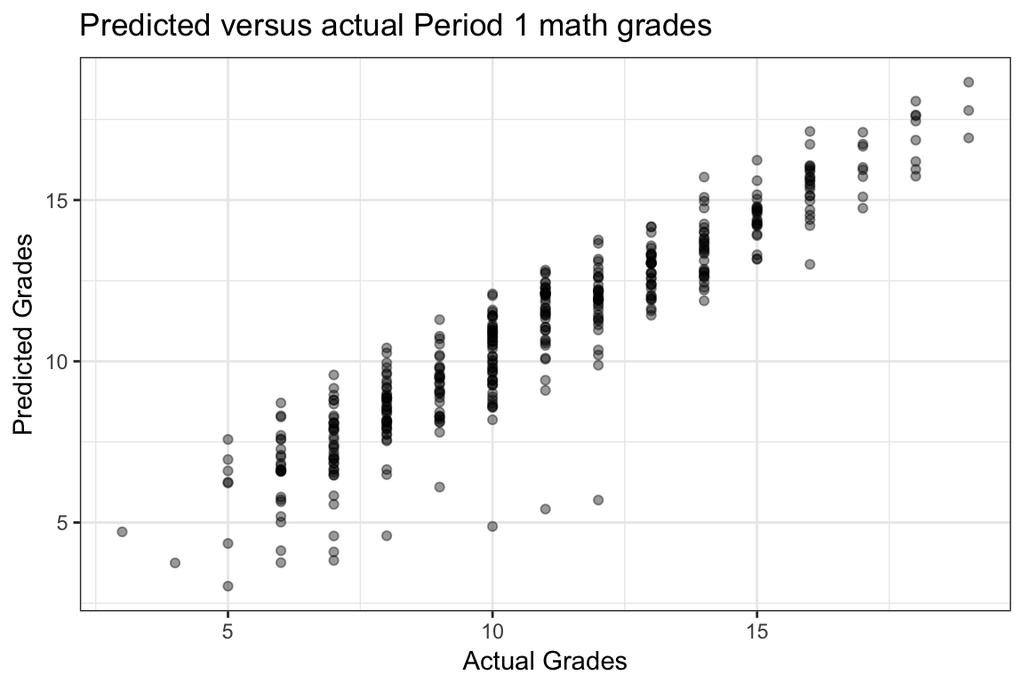

```r
library(ggplot2)

ggplot(data = student_m,
       mapping = aes(x = G1, y = G1_predicted)) +
  geom_point(alpha = .4) +   # Slightly transparent points
  theme_bw() +               # Use the black and white theme
  labs(title = 'Predicted versus actual Period 1 math grades',
       y = "Predicted Grades",
       x = "Actual Grades")
```

```r
# The model does a pretty good job I think
```

# Simulating results

29. In the following code chunk, I will create a dataframe called `df` that contains four predictors (A, B, C, D) and some random noise (noise). I will then create dv, a dependent variable that is a linear combination of the four predictors, plus the noise. Run the following chunk.

```r
library(tidyverse) # For dplyr

set.seed(100)  # Fix the randomisation

# Create a dataframe with 4 predictors (A, B, C and D) and noise

df <- data.frame(A = rnorm(n = 100, mean = 0, sd = 1),
                 B = rnorm(n = 100, mean = 0, sd = 1),
                 C = rnorm(n = 100, mean = 0, sd = 1),
                 D = rnorm(n = 100, mean = 0, sd = 1),
                 noise = rnorm(n = 100, mean = 0, sd = 10))

# Calculate y, a linear combination of A, B, C plus noise

df <- df %>%
  mutate(
    dv = 20 + A + 5 * B - 4 * C + 0 * D + noise
  )
```

30. If you were to conduct a regression analysis predicting `dv` as a function of the 4 predictors, what coefficients would you expect to get from the regression?

```r
# I would expect to get 20, 1, 5, -4 and 0
```

31. Test your prediction by conducting the appropriate analysis (*don’t* include the noise). Were you correct?

```r
lm_31 <- lm(dv ~ A + B + C + D,
            data = df)

summary(lm_31)
```

```
##
## Call:
## lm(formula = dv ~ A + B + C + D, data = df)
##
## Residuals:
##      Min       1Q   Median       3Q      Max
## -29.2071  -5.7369   0.9528   7.4823  20.6544
##
## Coefficients:
##             Estimate Std. Error t value Pr(>|t|)
## (Intercept)  18.6159     1.0804  17.231   <2e-16 ***
## A             0.7842     1.0748   0.730   0.4674
## B             4.1584     1.4213   2.926   0.0043 **
## C            -2.7358     1.0886  -2.513   0.0137 *
## D            -0.7390     1.0107  -0.731   0.4665
## ---
## Signif. codes:  0 '***' 0.001 '**' 0.01 '*' 0.05 '.' 0.1 ' ' 1
##
## Residual standard error: 10.77 on 95 degrees of freedom
## Multiple R-squared:  0.1722, Adjusted R-squared:  0.1374
## F-statistic: 4.942 on 4 and 95 DF,  p-value: 0.001157
```

```r
# I wasn't perfectly correct, but the numbers aren't too far off. The reason why they aren't perfect is because there is a lot of noise in the data.
```

32. Now repeat the analysis, but first change the standard deviation of the noise to something really small, like 0.01. What happens to the final regression coefficients?

```r
library(tidyverse) # For dplyr

set.seed(100)  # Fix the randomisation

# Create a dataframe with 4 predictors (A, B, C and D) and noise

df <- data.frame(A = rnorm(n = 100, mean = 0, sd = 1),
                 B = rnorm(n = 100, mean = 0, sd = 1),
                 C = rnorm(n = 100, mean = 0, sd = 1),
                 D = rnorm(n = 100, mean = 0, sd = 1),
                 noise = rnorm(n = 100, mean = 0, sd = .01))

# Calculate y, a linear combination of A, B, C plus noise

df <- df %>%
  mutate(
    dv = 20 + A + 5 * B - 4 * C + 0 * D + noise
  )

lm_32 <- lm(dv ~ A + B + C + D,
            data = df)

summary(lm_32)
```

```
##
## Call:
## lm(formula = dv ~ A + B + C + D, data = df)
##
## Residuals:
##        Min         1Q     Median         3Q        Max
## -0.0292071 -0.0057369  0.0009528  0.0074823  0.0206544
##
## Coefficients:
##              Estimate Std. Error   t value Pr(>|t|)
## (Intercept) 19.998616   0.001080 18511.175   <2e-16 ***
## A            0.999784   0.001075   930.180   <2e-16 ***
## B            4.999158   0.001421  3517.273   <2e-16 ***
## C           -3.998736   0.001089 -3673.147   <2e-16 ***
## D           -0.000739   0.001011    -0.731    0.466
## ---
## Signif. codes:  0 '***' 0.001 '**' 0.01 '*' 0.05 '.' 0.1 ' ' 1
##
## Residual standard error: 0.01077 on 95 degrees of freedom
## Multiple R-squared:      1,  Adjusted R-squared:      1
## F-statistic: 8.741e+06 on 4 and 95 DF,  p-value: < 2.2e-16
```

```r
# Now they are almost exactly as I predicted! That's because there's almost no noise in the data now...
```

## Submit!

- Save and email your `wpa_8_LastFirst.R` file to me at nathaniel.phillips@unibas.ch.
- Go to https://goo.gl/forms/b9dcRH6Ud3pDagOr1 to confirm your assignment submission.